# 003_PredictiveModeling_RandomForest

## Predictive Modelling with Random Forest on Road Accidents STATS19 dataset

Dataset includes data from years 2010 to 2015 for training and 2016 for testing

Approach: 1) Reviewed variables in the dataset to transform/derive new variables 2) Distribution of data guided the choice of predictive model 3) Train and test sets were used for model building; a separate hold-out test set from 2016 was also used for validation 4) Class imbalance was resolved with undersampling 5) Grid search was used for choosing best parameters 6) Cross validation enabled model validation 7) Performance was evaluated with ROC curve and confusion matrix

Random Forest was chosen due to following reasons: 1) Non-linearity in the dataset 2) Presence of categorical variables 3) Inability to draw much inferences on relationship between variables 4) Preference for a non-parametric approach without much assumptions

#### Load packages

```python
import csv
import os
import numpy as np
import pandas as pd
import matplotlib
import matplotlib.pyplot as plt
from pandas import ExcelWriter
from pandas import ExcelFile
from sklearn.preprocessing import LabelEncoder
import warnings
import pygeohash as pgh
from sklearn.cluster import KMeans
import matplotlib.cm as cm
from geopy.distance import great_circle
from geopy.distance import vincenty
from datetime import datetime
import seaborn as sns
from sklearn.model_selection import train_test_split, cross_val_score, GridSearchCV
from sklearn.ensemble import RandomForestClassifier, RandomForestRegressor
from sklearn import cross_validation
from sklearn.metrics import confusion_matrix, roc_curve
from sklearn.preprocessing import Imputer
from sklearn.metrics import classification_report
warnings.filterwarnings('ignore')
%matplotlib inline
get_ipython().magic('matplotlib inline')
matplotlib.rcParams.update({'font.size': 12})
matplotlib.rc('xtick', labelsize=8)
matplotlib.rc('ytick', labelsize=8)
np.random.seed(10)
%load_ext rpy2.ipython
```

#### Environment setting

```python
startTime = datetime.now()
wd = "C://MEJ//Data//"
os.chdir(wd)
del wd
```

#### Load pre-wrangled dataset

```python
csvData = pd.read_csv("BinarySeverity2010_2015.csv")
```

#### Check for sparsity in dataset

```python
print('Sparsity per variable in the dataset:')
((len(csvData.index) - csvData.count())/len(csvData.index))#Sparsity per variable retained
```

```
Sparsity per variable in the dataset:
```

```
Unnamed: 0                                 0.0
Vehicle_Reference                          0.0
Total Casualities                          0.0
Fatal                                      0.0
Serious                                    0.0
Slight                                     0.0
Pedestrian_Count                           0.0
Vehicle_Type                               0.0
Towing_and_Articulation                    0.0
Vehicle_Manoeuvre                          0.0
Vehicle_Location-Restricted_Lane           0.0
Junction_Location                          0.0
Skidding_and_Overturning                   0.0
Hit_Object_in_Carriageway                  0.0
Vehicle_Leaving_Carriageway                0.0
Hit_Object_off_Carriageway                 0.0
1st_Point_of_Impact                        0.0
Vehicle_Left_Hand_Drive                    0.0
Journey_Purpose_of_Driver                  0.0
Sex_of_Driver                              0.0
Age_of_Driver                              0.0
Age_Band_of_Driver                         0.0
Longitude                                  0.0
Latitude                                   0.0
Accident_Severity                          0.0
Number_of_Vehicles                         0.0
Number_of_Casualties                       0.0
Day_of_Week                                0.0
1st_Road_Class                             0.0
1st_Road_Number                            0.0
Road_Type                                  0.0
Speed_limit                                0.0
Junction_Detail                            0.0
Pedestrian_Crossing-Human_Control          0.0
Pedestrian_Crossing-Physical_Facilities    0.0
Light_Conditions                           0.0
Weather_Conditions                         0.0
Road_Surface_Conditions                    0.0
Special_Conditions_at_Site                 0.0
Carriageway_Hazards                        0.0
Urban_or_Rural_Area                        0.0
LSOA_of_Accident_Location                  0.0
circleDistLL                               0.0
Month                                      0.0
HourSlot                                   0.0
IntensityLabel                             0.0
dtype: float64
```

#### Data visualisation for assessing distribution of variables

##### Vehicle attributes

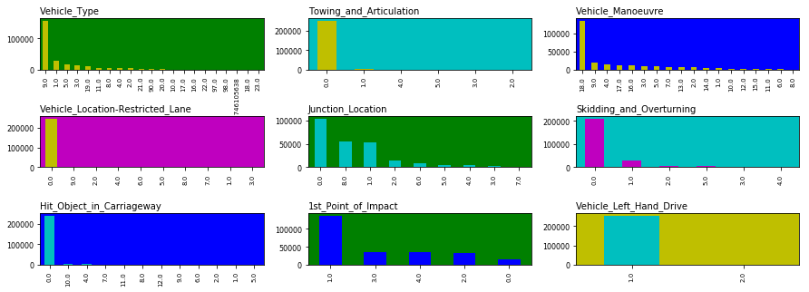

```python
plt.figure(figsize=(15,5))
plt.subplot(331,facecolor='g')
pd.value_counts(csvData['Vehicle_Type']).plot.bar(color='y')#Attribute on x-axis
plt.title('Vehicle_Type',loc='left',fontsize=10)
plt.xticks(fontsize=7)
plt.subplot(332,facecolor='c')
pd.value_counts(csvData['Towing_and_Articulation']).plot.bar(color='y')#Attribute on x-axis
plt.title('Towing_and_Articulation',loc='left',fontsize=10)
plt.xticks(fontsize=7)
plt.subplot(333,facecolor='b')
pd.value_counts(csvData['Vehicle_Manoeuvre']).plot.bar(color='y')#Attribute on x-axis
plt.title('Vehicle_Manoeuvre',loc='left',fontsize=10)
plt.xticks(fontsize=7)
plt.subplot(334,facecolor='m')
pd.value_counts(csvData['Vehicle_Location-Restricted_Lane']).plot.bar(color='y')#Attribute on x-axis
plt.title('Vehicle_Location-Restricted_Lane',loc='left',fontsize=10)
plt.xticks(fontsize=7)
plt.subplot(335,facecolor='g')
pd.value_counts(csvData['Junction_Location']).plot.bar(color='c')#Attribute on x-axis
plt.title('Junction_Location',loc='left',fontsize=10)
plt.xticks(fontsize=7)
plt.subplot(336,facecolor='c')
pd.value_counts(csvData['Skidding_and_Overturning']).plot.bar(color='m')#Attribute on x-axis
plt.title('Skidding_and_Overturning',loc='left',fontsize=10)
plt.xticks(fontsize=7)
plt.subplot(337,facecolor='b')
pd.value_counts(csvData['Hit_Object_in_Carriageway']).plot.bar(color='c')#Attribute on x-axis
plt.title('Hit_Object_in_Carriageway',loc='left',fontsize=10)
plt.xticks(fontsize=7)
plt.subplot(338,facecolor='g')
pd.value_counts(csvData['1st_Point_of_Impact']).plot.bar(color='b')#Attribute on x-axis
plt.title('1st_Point_of_Impact',loc='left',fontsize=10)
plt.xticks(fontsize=7)
plt.subplot(339,facecolor='y')
pd.value_counts(csvData['Vehicle_Left_Hand_Drive']).plot.bar(color='c')#Attribute on x-axis
plt.title('Vehicle_Left_Hand_Drive',loc='left',fontsize=10)
plt.xticks(fontsize=7)
plt.subplots_adjust(left=None, bottom=None, right=None, top=None, wspace=None, hspace=0.9)
plt.show()
```

##### Driver attributes

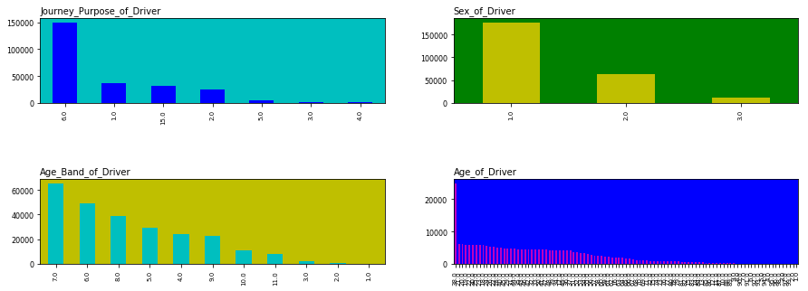

```python
plt.figure(figsize=(15,5))
plt.subplot(221,facecolor='c')
pd.value_counts(csvData['Journey_Purpose_of_Driver']).plot.bar(color='b')#Attribute on x-axis
plt.title('Journey_Purpose_of_Driver',loc='left',fontsize=10)
plt.xticks(fontsize=7)
plt.subplot(222,facecolor='g')
pd.value_counts(csvData['Sex_of_Driver']).plot.bar(color='y')#Attribute on x-axis
plt.title('Sex_of_Driver',loc='left',fontsize=10)
plt.xticks(fontsize=7)
plt.subplot(223,facecolor='y')
pd.value_counts(csvData['Age_Band_of_Driver']).plot.bar(color='c')#Attribute on x-axis
plt.title('Age_Band_of_Driver',loc='left',fontsize=10)
plt.xticks(fontsize=7)
plt.subplot(224,facecolor='b')
pd.value_counts(csvData['Age_of_Driver']).plot.bar(color='m')#Attribute on x-axis
plt.title('Age_of_Driver',loc='left',fontsize=10)
plt.xticks(fontsize=7)
plt.subplots_adjust(left=None, bottom=None, right=None, top=None, wspace=None, hspace=0.9)
plt.show()
```

##### Pedestrian attributes

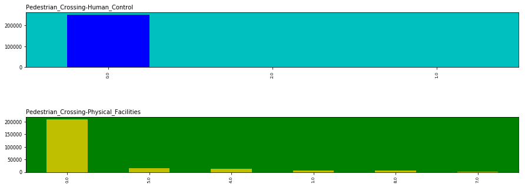

```python
plt.figure(figsize=(15,5))
plt.subplot(211,facecolor='c')
pd.value_counts(csvData['Pedestrian_Crossing-Human_Control']).plot.bar(color='b')#Attribute on x-axis
plt.title('Pedestrian_Crossing-Human_Control',loc='left',fontsize=10)
plt.xticks(fontsize=7)
plt.subplot(212,facecolor='g')
pd.value_counts(csvData['Pedestrian_Crossing-Physical_Facilities']).plot.bar(color='y')#Attribute on x-axis
plt.title('Pedestrian_Crossing-Physical_Facilities',loc='left',fontsize=10)
plt.xticks(fontsize=7)
plt.subplots_adjust(left=None, bottom=None, right=None, top=None, wspace=None, hspace=0.9)
plt.show()
```

##### Road attributes

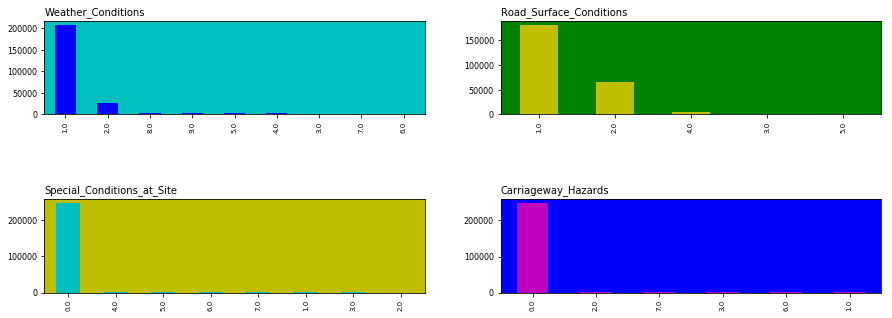

```python
plt.figure(figsize=(15,5))
plt.subplot(221,facecolor='c')
pd.value_counts(csvData['Weather_Conditions']).plot.bar(color='b')#Attribute on x-axis
plt.title('Weather_Conditions',loc='left',fontsize=10)
plt.xticks(fontsize=7)
plt.subplot(222,facecolor='g')
pd.value_counts(csvData['Road_Surface_Conditions']).plot.bar(color='y')#Attribute on x-axis
plt.title('Road_Surface_Conditions',loc='left',fontsize=10)
plt.xticks(fontsize=7)
plt.subplot(223,facecolor='y')
pd.value_counts(csvData['Special_Conditions_at_Site']).plot.bar(color='c')#Attribute on x-axis
plt.title('Special_Conditions_at_Site',loc='left',fontsize=10)
plt.xticks(fontsize=7)
plt.subplot(224,facecolor='b')
pd.value_counts(csvData['Carriageway_Hazards']).plot.bar(color='m')#Attribute on x-axis
plt.title('Carriageway_Hazards',loc='left',fontsize=10)
plt.xticks(fontsize=7)
plt.subplots_adjust(left=None, bottom=None, right=None, top=None, wspace=None, hspace=0.9)
plt.show()
```

#### Variable datatype

```python
print('Datatype of variables:')
csvData.dtypes#Checking variable data type as numeric type is most easy to deal with
```

```
Datatype of variables:
```

```
Unnamed: 0                                   int64
Vehicle_Reference                            int64
Total Casualities                            int64
Fatal                                        int64
Serious                                      int64
Slight                                       int64
Pedestrian_Count                             int64
Vehicle_Type                               float64
Towing_and_Articulation                    float64
Vehicle_Manoeuvre                          float64
Vehicle_Location-Restricted_Lane           float64
Junction_Location                          float64
Skidding_and_Overturning                   float64
Hit_Object_in_Carriageway                  float64
Vehicle_Leaving_Carriageway                float64
Hit_Object_off_Carriageway                 float64
1st_Point_of_Impact                        float64
Vehicle_Left_Hand_Drive                    float64
Journey_Purpose_of_Driver                  float64
Sex_of_Driver                              float64
Age_of_Driver                              float64
Age_Band_of_Driver                         float64
Longitude                                  float64
Latitude                                   float64
Accident_Severity                            int64
Number_of_Vehicles                           int64
Number_of_Casualties                         int64
Day_of_Week                                  int64
1st_Road_Class                               int64
1st_Road_Number                              int64
Road_Type                                    int64
Speed_limit                                  int64
Junction_Detail                            float64
Pedestrian_Crossing-Human_Control          float64
Pedestrian_Crossing-Physical_Facilities    float64
Light_Conditions                             int64
Weather_Conditions                         float64
Road_Surface_Conditions                    float64
Special_Conditions_at_Site                 float64
Carriageway_Hazards                        float64
Urban_or_Rural_Area                          int64
LSOA_of_Accident_Location                    int64
circleDistLL                               float64
Month                                        int64
HourSlot                                     int64
IntensityLabel                               int64
dtype: object
```

#### Correlation

|  | Unnamed: 0 | Vehicle_Reference | Total Casualities | Fatal | Serious | Slight | Pedestrian_Count | Vehicle_Type | Towing_and_Articulation | Vehicle_Manoeuvre | Vehicle_Location-Restricted_Lane | Junction_Location | Skidding_and_Overturning | Hit_Object_in_Carriageway | Vehicle_Leaving_Carriageway | Hit_Object_off_Carriageway | 1st_Point_of_Impact | Vehicle_Left_Hand_Drive | Journey_Purpose_of_Driver | Sex_of_Driver | Age_of_Driver | Age_Band_of_Driver | Longitude | Latitude | Accident_Severity | Number_of_Vehicles | Number_of_Casualties | Day_of_Week | 1st_Road_Class | … |
| --- | --- | --- | --- | --- | --- | --- | --- | --- | --- | --- | --- | --- | --- | --- | --- | --- | --- | --- | --- | --- | --- | --- | --- | --- | --- | --- | --- | --- | --- | --- |
| Unnamed: 0 | 1 | -0.000633544 | 0.00530421 | 0.00477906 | 0.00211128 | 0.00289623 | -0.00104488 | -0.00208741 | 0.00171134 | -0.000142661 | 0.00181848 | -0.00313931 | 0.00600785 | -0.00375621 | 0.00256446 | 0.00558096 | -0.000684994 | -0.000889384 | 0.00373327 | -0.000341607 | -0.000854679 | -0.00171762 | -0.00273768 | 0.00145562 | -0.00383508 | -0.00180849 | 0.00540338 | 0.00139723 | 0.000364381 | … |
| Vehicle_Reference | -0.000633544 | 1 | -0.0783095 | -0.0476636 | -0.123704 | 0.0199966 | -0.235794 | -0.0291055 | 0.000186453 | -0.0721546 | -0.0134032 | 0.033152 | -0.0920769 | -0.0758233 | -0.105612 | -0.113661 | 0.00696669 | -0.00630493 | 0.0060052 | 0.0234753 | 0.0178791 | 0.0239755 | 0.0052151 | -0.0122316 | 0.111159 | 0.641138 | 0.31025 | 0.00615086 | -0.0899817 | … |
| Total Casualities | 0.00530421 | -0.0783095 | 1 | 0.118313 | 0.428138 | 0.733277 | 0.117647 | -0.0493631 | -0.0283614 | 0.152506 | 0.00302385 | -0.0551205 | 0.145629 | 0.0816915 | 0.154557 | 0.170961 | -0.00664712 | -0.0195211 | 0.0323264 | -0.0822192 | -0.0299894 | -0.0470657 | -0.0361145 | 0.0402046 | -0.282014 | -0.113049 | 0.52322 | -0.00227088 | -0.0168909 | … |
| Fatal | 0.00477906 | -0.0476636 | 0.118313 | 1 | -0.102497 | -0.0633528 | 0.0450481 | 0.0169242 | 0.00919074 | 0.0712826 | 0.00467514 | -0.0626284 | 0.0660909 | 0.0419103 | 0.0981512 | 0.0901512 | -0.00968845 | 0.00330134 | 0.0107892 | -0.0517797 | 0.0360889 | 0.0297405 | -0.0197927 | 0.0145633 | -0.46988 | -0.0217806 | 0.0725189 | -0.0038871 | -0.0483202 | … |
| Serious | 0.00211128 | -0.123704 | 0.428138 | -0.102497 | 1 | -0.253034 | 0.191868 | -0.0850155 | -0.0194897 | 0.226406 | 0.0201451 | -0.0575148 | 0.134578 | 0.0757163 | 0.136919 | 0.135487 | -0.0359753 | -0.0189617 | 0.0244459 | -0.113958 | -0.00259323 | -0.0194076 | -0.0323774 | 0.0269403 | -0.689193 | -0.169577 | 0.126827 | -0.00575427 | 0.0359675 | … |
| Slight | 0.00289623 | 0.0199966 | 0.733277 | -0.0633528 | -0.253034 | 1 | -0.0274119 | 0.00526249 | -0.0186879 | -0.0223745 | -0.0129727 | -0.00013998 | 0.039926 | 0.0209345 | 0.0392702 | 0.0602569 | 0.0221741 | -0.00792313 | 0.013943 | 0.00960665 | -0.0402364 | -0.0445237 | -0.00973155 | 0.0196126 | 0.333329 | 0.00956729 | 0.453171 | 0.00286414 | -0.0321375 | … |
| Pedestrian_Count | -0.00104488 | -0.235794 | 0.117647 | 0.0450481 | 0.191868 | -0.0274119 | 1 | 0.0775166 | -0.0017346 | 0.028541 | 0.0654608 | -0.0895902 | -0.108292 | -0.0437026 | -0.0963343 | -0.0948402 | 0.0154585 | -0.00657882 | -0.0321684 | 0.0840996 | 0.0480687 | 0.0585555 | -0.00894779 | 0.0246733 | -0.186439 | -0.335774 | -0.0824312 | 0.0181233 | 0.137264 | … |
| Vehicle_Type | -0.00208741 | -0.0291055 | -0.0493631 | 0.0169242 | -0.0850155 | 0.00526249 | 0.0775166 | 1 | 0.106701 | -0.0826019 | 0.00970842 | -0.0650645 | 0.0223856 | -0.0123614 | 0.0155484 | 0.0246368 | -0.000828387 | 0.047102 | -0.0780956 | 0.0490825 | 0.0884864 | 0.0974706 | -0.0185441 | 0.0227922 | 0.0596081 | 0.00253834 | 0.0450137 | 0.00380361 | -0.0261443 | … |
| Towing_and_Articulation | 0.00171134 | 0.000186453 | -0.0283614 | 0.00919074 | -0.0194897 | -0.0186879 | -0.0017346 | 0.106701 | 1 | 0.00132916 | 0.00114156 | -0.0287435 | 0.0438546 | -0.00409158 | -0.000719779 | 0.00630495 | 0.0146364 | 0.0746422 | -0.0536065 | -0.028408 | 0.0300516 | 0.0316665 | -0.0137934 | 0.0145061 | -0.000475367 | 0.0118402 | 0.00655866 | -0.00248235 | -0.0470906 | … |
| Vehicle_Manoeuvre | -0.000142661 | -0.0721546 | 0.152506 | 0.0712826 | 0.226406 | -0.0223745 | 0.028541 | -0.0826019 | 0.00132916 | 1 | -0.045044 | -0.0318526 | 0.13103 | 0.0786211 | 0.117018 | 0.127027 | -0.0742813 | -0.00657915 | 0.0243047 | -0.0920183 | -0.0530868 | -0.0644289 | -0.0264293 | 0.0219986 | -0.233971 | -0.113204 | 0.0159169 | -0.0135372 | -0.00990933 | … |
| Vehicle_Location-Restricted_Lane | 0.00181848 | -0.0134032 | 0.00302385 | 0.00467514 | 0.0201451 | -0.0129727 | 0.0654608 | 0.00970842 | 0.00114156 | -0.045044 | 1 | -0.00372243 | -0.015883 | 0.023838 | 0.00202667 | 0.00694755 | -0.00582779 | -0.00319079 | 0.00113839 | 0.0102679 | -0.00462508 | -0.0102013 | 0.00982023 | 0.0010851 | -0.0220347 | -0.0333081 | -0.0256508 | 0.00362648 | 0.03662 | … |
| Junction_Location | -0.00313931 | 0.033152 | -0.0551205 | -0.0626284 | -0.0575148 | -0.00013998 | -0.0895902 | -0.0650645 | -0.0287435 | -0.0318526 | -0.00372243 | 1 | -0.0986617 | -0.0534579 | -0.0951371 | -0.114689 | 0.073757 | -0.0113311 | -0.00162163 | -0.0276808 | -0.000453804 | -0.000736858 | 0.0626079 | -0.0259004 | 0.0845795 | 0.00282404 | -0.0482693 | 0.0034115 | 0.0174234 | … |
| Skidding_and_Overturning | 0.00600785 | -0.0920769 | 0.145629 | 0.0660909 | 0.134578 | 0.039926 | -0.108292 | 0.0223856 | 0.0438546 | 0.13103 | -0.015883 | -0.0986617 | 1 | 0.134369 | 0.249783 | 0.275289 | 0.0113003 | -0.000532813 | 0.0146228 | -0.0639218 | -0.0561871 | -0.0637292 | -0.0474602 | 0.0327347 | -0.132494 | -0.0817392 | 0.035155 | -0.0123401 | -0.0387466 | … |
| Hit_Object_in_Carriageway | -0.00375621 | -0.0758233 | 0.0816915 | 0.0419103 | 0.0757163 | 0.0209345 | -0.0437026 | -0.0123614 | -0.00409158 | 0.0786211 | 0.023838 | -0.0534579 | 0.134369 | 1 | 0.176946 | 0.183087 | -0.00206147 | -0.0064029 | 0.0239114 | -0.0352159 | -0.024261 | -0.0280073 | 0.00868102 | -0.00116858 | -0.0772791 | -0.0666106 | -0.00180204 | -0.0109279 | 0.014313 | … |
| Vehicle_Leaving_Carriageway | 0.00256446 | -0.105612 | 0.154557 | 0.0981512 | 0.136919 | 0.0392702 | -0.0963343 | 0.0155484 | -0.000719779 | 0.117018 | 0.00202667 | -0.0951371 | 0.249783 | 0.176946 | 1 | 0.534364 | 0.0093048 | -0.00118769 | 0.0282149 | -0.0480456 | -0.0339679 | -0.0426675 | -0.0226952 | 0.0341694 | -0.150422 | -0.100333 | 0.0549354 | -0.00998584 | -0.0207701 | … |
| Hit_Object_off_Carriageway | 0.00558096 | -0.113661 | 0.170961 | 0.0901512 | 0.135487 | 0.0602569 | -0.0948402 | 0.0246368 | 0.00630495 | 0.127027 | 0.00694755 | -0.114689 | 0.275289 | 0.183087 | 0.534364 | 1 | 0.00404952 | 0.00123663 | 0.0305269 | -0.0426008 | -0.03308 | -0.0424193 | -0.0455461 | 0.0401884 | -0.141173 | -0.13043 | 0.0449648 | -0.0120966 | -0.023557 | … |
| 1st_Point_of_Impact | -0.000684994 | 0.00696669 | -0.00664712 | -0.00968845 | -0.0359753 | 0.0221741 | 0.0154585 | -0.000828387 | 0.0146364 | -0.0742813 | -0.00582779 | 0.073757 | 0.0113003 | -0.00206147 | 0.0093048 | 0.00404952 | 1 | 0.0067563 | -0.000771618 | 0.00607436 | 0.0143662 | 0.0144519 | 0.0314853 | -0.00710271 | 0.0383787 | -0.018256 | -0.0374488 | 0.00127156 | -0.0103611 | … |
| Vehicle_Left_Hand_Drive | -0.000889384 | -0.00630493 | -0.0195211 | 0.00330134 | -0.0189617 | -0.00792313 | -0.00657882 | 0.047102 | 0.0746422 | -0.00657915 | -0.00319079 | -0.0113311 | -0.000532813 | -0.0064029 | -0.00118769 | 0.00123663 | 0.0067563 | 1 | -0.0264838 | -0.00836955 | 0.000101732 | 0.00213688 | 0.0115711 | -0.000709248 | 0.0134646 | 0.00615859 | 0.00649868 | -0.000205499 | -0.0362477 | … |
| Journey_Purpose_of_Driver | 0.00373327 | 0.0060052 | 0.0323264 | 0.0107892 | 0.0244459 | 0.013943 | -0.0321684 | -0.0780956 | -0.0536065 | 0.0243047 | 0.00113839 | -0.00162163 | 0.0146228 | 0.0239114 | 0.0282149 | 0.0305269 | -0.000771618 | -0.0264838 | 1 | 0.0790369 | -0.0142805 | -0.023287 | -0.0148219 | -0.0104882 | -0.0129125 | 0.0117652 | 0.0265622 | 0.00376862 | 0.031945 | … |
| Sex_of_Driver | -0.000341607 | 0.0234753 | -0.0822192 | -0.0517797 | -0.113958 | 0.00960665 | 0.0840996 | 0.0490825 | -0.028408 | -0.0920183 | 0.0102679 | -0.0276808 | -0.0639218 | -0.0352159 | -0.0480456 | -0.0426008 | 0.00607436 | -0.00836955 | 0.0790369 | 1 | -0.00212544 | 0.026352 | -0.00235258 | -0.00351335 | 0.129298 | 0.0133196 | -0.00991935 | -0.00128108 | 0.0521298 | … |
| Age_of_Driver | -0.000854679 | 0.0178791 | -0.0299894 | 0.0360889 | -0.00259323 | -0.0402364 | 0.0480687 | 0.0884864 | 0.0300516 | -0.0530868 | -0.00462508 | -0.000453804 | -0.0561871 | -0.024261 | -0.0339679 | -0.03308 | 0.0143662 | 0.000101732 | -0.0142805 | -0.00212544 | 1 | 0.977478 | -0.0188116 | 0.00583411 | -0.0351767 | 0.02032 | 0.0220223 | -0.00481917 | -0.0458134 | … |
| Age_Band_of_Driver | -0.00171762 | 0.0239755 | -0.0470657 | 0.0297405 | -0.0194076 | -0.0445237 | 0.0585555 | 0.0974706 | 0.0316665 | -0.0644289 | -0.0102013 | -0.000736858 | -0.0637292 | -0.0280073 | -0.0426675 | -0.0424193 | 0.0144519 | 0.00213688 | -0.023287 | 0.026352 | 0.977478 | 1 | -0.010276 | 0.00167297 | -0.0183055 | 0.022908 | 0.0188199 | -0.00464642 | -0.0555121 | … |
| Longitude | -0.00273768 | 0.0052151 | -0.0361145 | -0.0197927 | -0.0323774 | -0.00973155 | -0.00894779 | -0.0185441 | -0.0137934 | -0.0264293 | 0.00982023 | 0.0626079 | -0.0474602 | 0.00868102 | -0.0226952 | -0.0455461 | 0.0314853 | 0.0115711 | -0.0148219 | -0.00235258 | -0.0188116 | -0.010276 | 1 | -0.233828 | 0.0396709 | 1.31243e-05 | -0.0349726 | 0.00260381 | -0.0453631 | … |
| Latitude | 0.00145562 | -0.0122316 | 0.0402046 | 0.0145633 | 0.0269403 | 0.0196126 | 0.0246733 | 0.0227922 | 0.0145061 | 0.0219986 | 0.0010851 | -0.0259004 | 0.0327347 | -0.00116858 | 0.0341694 | 0.0401884 | -0.00710271 | -0.000709248 | -0.0104882 | -0.00351335 | 0.00583411 | 0.00167297 | -0.233828 | 1 | -0.0282404 | -0.0156184 | 0.0324974 | 0.00142299 | 0.0399918 | … |
| Accident_Severity | -0.00383508 | 0.111159 | -0.282014 | -0.46988 | -0.689193 | 0.333329 | -0.186439 | 0.0596081 | -0.000475367 | -0.233971 | -0.0220347 | 0.0845795 | -0.132494 | -0.0772791 | -0.150422 | -0.141173 | 0.0383787 | 0.0134646 | -0.0129125 | 0.129298 | -0.0351767 | -0.0183055 | 0.0396709 | -0.0282404 | 1 | 0.134849 | -0.0785992 | 0.00842445 | -0.00530777 | … |
| Number_of_Vehicles | -0.00180849 | 0.641138 | -0.113049 | -0.0217806 | -0.169577 | 0.00956729 | -0.335774 | 0.00253834 | 0.0118402 | -0.113204 | -0.0333081 | 0.00282404 | -0.0817392 | -0.0666106 | -0.100333 | -0.13043 | -0.018256 | 0.00615859 | 0.0117652 | 0.0133196 | 0.02032 | 0.022908 | 1.31243e-05 | -0.0156184 | 0.134849 | 1 | 0.478504 | 0.00638483 | -0.141478 | … |
| Number_of_Casualties | 0.00540338 | 0.31025 | 0.52322 | 0.0725189 | 0.126827 | 0.453171 | -0.0824312 | 0.0450137 | 0.00655866 | 0.0159169 | -0.0256508 | -0.0482693 | 0.035155 | -0.00180204 | 0.0549354 | 0.0449648 | -0.0374488 | 0.00649868 | 0.0265622 | -0.00991935 | 0.0220223 | 0.0188199 | -0.0349726 | 0.0324974 | -0.0785992 | 0.478504 | 1 | 0.00442442 | -0.0995885 | … |
| Day_of_Week | 0.00139723 | 0.00615086 | -0.00227088 | -0.0038871 | -0.00575427 | 0.00286414 | 0.0181233 | 0.00380361 | -0.00248235 | -0.0135372 | 0.00362648 | 0.0034115 | -0.0123401 | -0.0109279 | -0.00998584 | -0.0120966 | 0.00127156 | -0.000205499 | 0.00376862 | -0.00128108 | -0.00481917 | -0.00464642 | 0.00260381 | 0.00142299 | 0.00842445 | 0.00638483 | 0.00442442 | 1 | 0.00737867 | … |
| 1st_Road_Class | 0.000364381 | -0.0899817 | -0.0168909 | -0.0483202 | 0.0359675 | -0.0321375 | 0.137264 | -0.0261443 | -0.0470906 | -0.00990933 | 0.03662 | 0.0174234 | -0.0387466 | 0.014313 | -0.0207701 | -0.023557 | -0.0103611 | -0.0362477 | 0.031945 | 0.0521298 | -0.0458134 | -0.0555121 | -0.0453631 | 0.0399918 | -0.00530777 | -0.141478 | -0.0995885 | 0.00737867 | 1 | … |
| 1st_Road_Number | 0.00178965 | -0.010046 | 0.00514761 | -0.000865347 | 0.0134877 | -0.00423086 | 0.00731323 | -0.0136928 | -0.012852 | 0.0144158 | -0.000701174 | 0.0266223 | 0.000481782 | 0.00195486 | 0.00374968 | 0.000465268 | -0.00352055 | -0.0117565 | -0.00299507 | -0.00390875 | -0.00336843 | -0.00514169 | -0.124344 | 0.0886842 | -0.0128861 | -0.0246174 | -0.00694587 | 3.42622e-05 | -0.0699941 | … |
| Road_Type | -0.000807782 | -0.0575063 | 0.0239171 | 0.00891464 | 0.0666324 | -0.0260744 | 0.078555 | -0.0121665 | -0.0307121 | 0.0227696 | 0.0241403 | -0.084804 | -0.0140214 | -0.0128884 | 0.0257648 | 0.00922425 | -0.0487468 | -0.0297717 | 0.0324686 | 0.0115593 | -0.0118796 | -0.0178992 | -0.00978444 | 0.00412169 | -0.0692367 | -0.0724114 | -0.0186025 | 0.00300147 | 0.293394 | … |
| Speed_limit | -0.00142129 | 0.0691444 | 0.0991527 | 0.114238 | 0.0582682 | 0.033472 | -0.22669 | 0.0574478 | 0.0774393 | 0.103363 | -0.0552675 | -0.22306 | 0.207382 | 0.00571299 | 0.206213 | 0.214445 | -0.0262831 | 0.0442419 | -0.0116567 | -0.0507746 | 0.050349 | 0.0465665 | -0.0456965 | 0.0243826 | -0.119735 | 0.135625 | 0.17337 | -0.0197962 | -0.389065 | … |
| Junction_Detail | -0.00122482 | 0.0291423 | -0.0515306 | -0.0561666 | -0.0565319 | 0.00128768 | -0.00937845 | -0.0312564 | -0.0287103 | -0.0826251 | 0.0415454 | 0.523471 | -0.106318 | -0.0638652 | -0.0983886 | -0.120348 | 0.0179068 | -0.0164717 | 0.000348196 | -0.00773377 | 0.00181752 | 0.00135922 | 0.0150179 | 6.12078e-05 | 0.0795199 | 0.0099622 | -0.0371207 | 0.0082372 | 0.056364 | … |
| Pedestrian_Crossing-Human_Control | 0.00223401 | -0.00745592 | 0.000983835 | -0.00420369 | -0.000308018 | 0.00242155 | 0.0349453 | 0.00447936 | -0.000554301 | -0.00163911 | -0.00147108 | 0.00263512 | -0.00702216 | -0.00913282 | -0.0112994 | -0.01303 | -0.000775811 | -0.00114573 | -0.00770659 | 0.00546909 | 0.00557159 | 0.00514739 | -0.00845663 | 0.0113057 | 0.00286344 | -0.0140191 | -0.00666019 | 0.00129036 | 0.0023913 | … |
| Pedestrian_Crossing-Physical_Facilities | -0.000699641 | -0.0328131 | -0.017325 | -0.0200362 | -0.0096743 | -0.00620584 | 0.138124 | -0.00341482 | -0.0172253 | -0.0311521 | -0.00346165 | 0.140311 | -0.0729168 | -0.00885918 | -0.082147 | -0.0886749 | 0.0180239 | -0.00647062 | -0.0240026 | 0.00148876 | -0.00817574 | -0.00309229 | 0.0646472 | -0.0150935 | 0.0202353 | -0.0644505 | -0.0449473 | 0.0065927 | -0.0965609 | … |
| Light_Conditions | 0.000648245 | -0.0426335 | 0.0770996 | 0.0730903 | 0.0681363 | 0.013249 | 0.0183421 | -0.0011782 | -0.00787873 | 0.0825083 | -0.018255 | -0.0475073 | 0.0875826 | 0.0560505 | 0.100902 | 0.11333 | -0.022895 | 0.00349587 | 0.0154216 | -0.0250316 | -0.111718 | -0.108362 | 0.0114255 | -0.00389342 | -0.0914975 | -0.0553099 | 0.0283953 | 0.0118229 | -0.0400935 | … |
| Weather_Conditions | -0.00178629 | 0.0152904 | 0.00197749 | -0.0036452 | -0.0157948 | 0.0148781 | -0.00618099 | 0.0151896 | 0.00334033 | 0.000398145 | 0.00215637 | -0.0312159 | 0.0212782 | 0.00510599 | 0.0142022 | 0.0185832 | -0.0125597 | 0.00237117 | -0.000525846 | 0.0220755 | -0.0187051 | -0.0154912 | -0.0104689 | 0.0108391 | 0.0199981 | 0.0177146 | 0.0269175 | -0.000873777 | 0.00391713 | … |
| Road_Surface_Conditions | 0.000137909 | -0.0114084 | 0.0275153 | 0.00707724 | 0.00039953 | 0.0276252 | -0.0353752 | 0.0200337 | -0.00604462 | 0.0325337 | -0.0162078 | -0.0581241 | 0.0914523 | 0.0147646 | 0.0798777 | 0.0898882 | -0.0161605 | -0.00160648 | -0.012954 | 0.00802357 | -0.0299629 | -0.0302248 | -0.0386015 | 0.0428121 | 0.00229356 | -0.010428 | 0.0283447 | -0.000404715 | 0.00448422 | … |
| Special_Conditions_at_Site | 0.00435924 | -0.00874129 | 0.00873629 | -0.00791913 | 0.00719532 | 0.00623221 | -0.0333343 | 0.00427712 | 0.0067643 | 0.00924295 | -0.00633489 | -0.0402336 | 0.0401376 | 0.00882635 | 0.0182136 | 0.022751 | -0.0013738 | 0.00563947 | -0.00904452 | -0.00884438 | 0.00275025 | 0.00207166 | -0.0101596 | 0.00841001 | -0.000367358 | -0.00672581 | 0.00680866 | -0.000631388 | -0.00911399 | … |
| Carriageway_Hazards | -0.000874955 | -0.0106813 | 0.017083 | -0.000772819 | 0.0114282 | 0.010212 | -0.011911 | 0.00112494 | 0.00301381 | 0.0187399 | -0.00324777 | -0.0545708 | 0.0336515 | 0.158132 | 0.027399 | 0.0327743 | -0.0234702 | -0.00170445 | -0.00566592 | -0.00575723 | -0.00893048 | -0.0091253 | 0.00246518 | -0.0044415 | -0.00909502 | -0.0112725 | 0.00914815 | -0.00437893 | -0.0130069 | … |
| Urban_or_Rural_Area | -0.00049135 | 0.0368529 | 0.097987 | 0.0994783 | 0.0796498 | 0.0202448 | -0.20966 | 0.0426505 | 0.059385 | 0.108087 | -0.0488159 | -0.208406 | 0.195262 | 0.0109242 | 0.207569 | 0.209079 | -0.0364333 | 0.0245218 | 0.000213108 | -0.0414619 | 0.0652493 | 0.0550509 | -0.0879549 | 0.0225677 | -0.130755 | 0.0840834 | 0.143469 | -0.0221267 | -0.227475 | … |
| LSOA_of_Accident_Location | 0.00219422 | 0.0140283 | 0.046064 | 0.0425982 | 0.06349 | -0.00875737 | -0.0890297 | 0.021375 | 0.0326632 | 0.051794 | 0.00834051 | -0.14861 | 0.111811 | -0.0150276 | 0.113683 | 0.106708 | -0.038248 | 0.0148786 | -0.0242324 | 0.00430476 | 0.0526914 | 0.0356424 | -0.158279 | -0.0720852 | -0.0862498 | 0.0365085 | 0.0616048 | -0.00456972 | 0.000355405 | … |
| circleDistLL | 0.00196911 | -0.0108646 | 0.0562125 | 0.0252422 | 0.0499419 | 0.016976 | 0.00833536 | 0.0272917 | 0.0196906 | 0.0413518 | -0.00362104 | -0.0878519 | 0.0657142 | -0.0165957 | 0.0509245 | 0.0690978 | -0.0329077 | -0.00587877 | 0.0024172 | 0.00331037 | 0.0302337 | 0.0176217 | -0.728081 | 0.730916 | -0.0568899 | -0.00668902 | 0.0532049 | -0.000261227 | 0.0800892 | … |
| Month | -0.00197687 | 0.00268147 | -0.000644998 | 0.00455224 | 0.00279268 | -0.00399747 | 0.00430784 | -0.000255092 | -0.00095334 | 0.00406692 | 0.00234627 | 0.0020608 | -0.00433025 | -0.000564841 | -0.00675897 | -0.00689972 | -0.00428888 | 0.00230505 | -0.00171553 | 0.00307871 | 0.00269764 | 0.00198403 | 0.00390582 | -0.000545795 | -0.00537307 | 0.00377911 | 0.00356736 | -0.000665507 | -0.00346946 | … |
| HourSlot | 0.000783646 | -0.0014469 | 0.00352532 | -0.0156055 | 0.00434115 | 0.00476888 | 0.0272665 | -0.0298823 | -0.0150202 | 0.00166869 | -0.00550942 | 0.0160518 | -0.0277319 | -0.0241655 | -0.0335336 | -0.0395577 | 0.00153551 | -0.00448945 | 0.108186 | -0.00443323 | -0.0379105 | -0.0434957 | -0.00985628 | 0.0161698 | 0.00532036 | -0.00458658 | 0.0116092 | 0.0342771 | 0.0428021 | … |
| IntensityLabel | 0.00325238 | -0.148913 | 0.3328 | 0.188617 | 0.878869 | -0.344156 | 0.224595 | -0.0963182 | -0.0181234 | 0.258798 | 0.0250925 | -0.0702483 | 0.140781 | 0.082997 | 0.147039 | 0.142348 | -0.0386569 | -0.0222747 | 0.0176874 | -0.137626 | 0.0152836 | -0.00364903 | -0.0355515 | 0.0275995 | -0.885518 | -0.197799 | 0.0360542 | -0.0074229 | 0.0346758 | … |

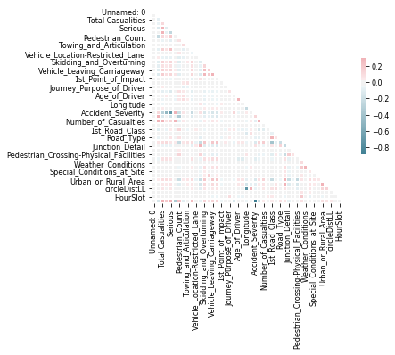

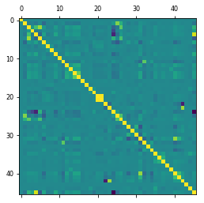

```python
corr = csvData.corr()
cmap = sns.diverging_palette(220, 10, as_cmap=True)
mask = np.zeros_like(corr, dtype=np.bool)
mask[np.triu_indices_from(mask)] = True
sns.heatmap(corr, mask=mask, cmap=cmap, vmax=.3, center=0,square=True, linewidths=.5, cbar_kws={"shrink": .5})

dataCorrelation = pd.DataFrame(csvData.corr())
plt.matshow(csvData.corr())

def colorPandasDF_redOrGreen(val):
    color = 'red' if val < 0.5 else 'green'
    return 'color: %s' % color
dataCorrelation.style.applymap(colorPandasDF_redOrGreen)
```

#### Class label distribution

```python
#classDistribution = dataset['Accident_Severity'].value_counts()
classDistribution = csvData['IntensityLabel'].value_counts()
print('Class imbalance:')
print(classDistribution)
```

```
Class imbalance:
1    125863
0    125863
Name: IntensityLabel, dtype: int64
```

```python
print('Printing dataset columns to review variables to be removed ==> \n', csvData.columns)
```

```
Printing dataset columns to review variables to be removed ==>
 Index(['Unnamed: 0', 'Vehicle_Reference', 'Total Casualities', 'Fatal',
       'Serious', 'Slight', 'Pedestrian_Count', 'Vehicle_Type',
       'Towing_and_Articulation', 'Vehicle_Manoeuvre',
       'Vehicle_Location-Restricted_Lane', 'Junction_Location',
       'Skidding_and_Overturning', 'Hit_Object_in_Carriageway',
       'Vehicle_Leaving_Carriageway', 'Hit_Object_off_Carriageway',
       '1st_Point_of_Impact', 'Vehicle_Left_Hand_Drive',
       'Journey_Purpose_of_Driver', 'Sex_of_Driver', 'Age_of_Driver',
       'Age_Band_of_Driver', 'Longitude', 'Latitude', 'Accident_Severity',
       'Number_of_Vehicles', 'Number_of_Casualties', 'Day_of_Week',
       '1st_Road_Class', '1st_Road_Number', 'Road_Type', 'Speed_limit',
       'Junction_Detail', 'Pedestrian_Crossing-Human_Control',
       'Pedestrian_Crossing-Physical_Facilities', 'Light_Conditions',
       'Weather_Conditions', 'Road_Surface_Conditions',
       'Special_Conditions_at_Site', 'Carriageway_Hazards',
       'Urban_or_Rural_Area', 'LSOA_of_Accident_Location', 'circleDistLL',
       'Month', 'HourSlot', 'IntensityLabel'],
      dtype='object')
```

#### Remove redundant variables

```python
csvData.drop(['LSOA_of_Accident_Location'],axis=1,inplace=True)
csvData.drop(['Fatal','Serious','Slight','Number_of_Vehicles','Pedestrian_Count'], axis=1, inplace=True)
csvData.drop(['Accident_Severity','Total Casualities'], axis=1, inplace=True)
csvData.drop(['Latitude','Longitude'],axis=1,inplace=True)
```

#### Remove misleading records

```python
#data = data[~data['Vehicle_Type'].isin([10,11,18,])]
```

#### Review and save final dataset

```python
csvData.reset_index()
predictors = list(csvData.columns)
#recordsPerLSOA = data.LSOA_of_Accident_Location.value_counts()
print('Total no. of predictors ==> ',len(predictors))
print('Predictors ==> ', predictors)
print('Datatype of variables ==> ')
#dataType = csvData.dtypes#Checking variable data type as numeric type is most easy to deal with
print(csvData.dtypes.value_counts())
csvData.to_csv('datasetForModeling.csv')
print('Printing sample records from dataset ==>')
csvData.head(2)
#data.tail(2)
```

```
Total no. of predictors ==>  36
Predictors ==>  ['Unnamed: 0', 'Vehicle_Reference', 'Vehicle_Type', 'Towing_and_Articulation', 'Vehicle_Manoeuvre', 'Vehicle_Location-Restricted_Lane', 'Junction_Location', 'Skidding_and_Overturning', 'Hit_Object_in_Carriageway', 'Vehicle_Leaving_Carriageway', 'Hit_Object_off_Carriageway', '1st_Poin…
Datatype of variables ==>
float64    23
int64      13
dtype: int64
Printing sample records from dataset ==>
```

|  | Unnamed: 0 | Vehicle_Reference | Vehicle_Type | Towing_and_Articulation | Vehicle_Manoeuvre | Vehicle_Location-Restricted_Lane | Junction_Location | Skidding_and_Overturning | Hit_Object_in_Carriageway | Vehicle_Leaving_Carriageway | ... | Light_Conditions | Weather_Conditions | Road_Surface_Conditions | Special_Conditions_at_Site | Carriageway_Hazards | Urban_or_Rural_Area | circleDistLL | Month | HourSlot | IntensityLabel |
| --- | --- | --- | --- | --- | --- | --- | --- | --- | --- | --- | --- | --- | --- | --- | --- | --- | --- | --- | --- | --- | --- |
| 0 | 0 | 2 | 1.0 | 0.0 | 18.0 | 0.0 | 1.0 | 0.0 | 0.0 | 0.0 | ... | 1 | 1.0 | 1.0 | 0.0 | 0.0 | 1 | 174.787727 | 11 | 4 | 1 |
| 1 | 1 | 1 | 9.0 | 0.0 | 9.0 | 0.0 | 5.0 | 0.0 | 0.0 | 0.0 | ... | 1 | 1.0 | 1.0 | 0.0 | 0.0 | 1 | 90.195772 | 8 | 4 | 0 |

2 rows × 36 columns

### Dataset for modeling

```python
modelDataTraining = csvData.copy(deep=True)
```

#### Correlation (repeated)

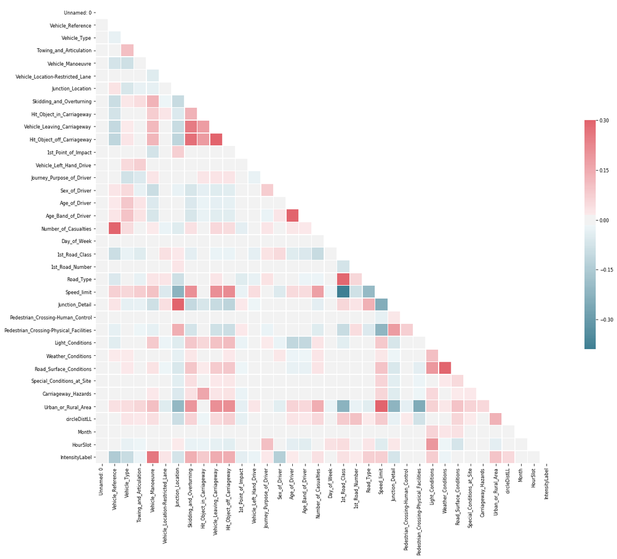

```python
plt.subplots(figsize=(20,15))
corr = modelDataTraining.corr()
cmap = sns.diverging_palette(220, 10, as_cmap=True)
mask = np.zeros_like(corr, dtype=np.bool)
mask[np.triu_indices_from(mask)] = True
sns.heatmap(corr, mask=mask, cmap=cmap, vmax=.3, center=0,square=True, linewidths=.5, cbar_kws={"shrink": .5})
```

```python
dataCorrelation = pd.DataFrame(modelDataTraining.corr())
#plt.matshow(data.corr())
def colorPandasDF_redOrGreen(val):
    color = 'red' if val < 0.5 else 'green'
    return 'color: %s' % color
dataCorrelation.style.applymap(colorPandasDF_redOrGreen)
```

|  | Unnamed: 0 | Vehicle_Reference | Vehicle_Type | Towing_and_Articulation | Vehicle_Manoeuvre | Vehicle_Location-Restricted_Lane | Junction_Location | Skidding_and_Overturning | Hit_Object_in_Carriageway | Vehicle_Leaving_Carriageway | Hit_Object_off_Carriageway | 1st_Point_of_Impact | Vehicle_Left_Hand_Drive | Journey_Purpose_of_Driver | Sex_of_Driver | Age_of_Driver | Age_Band_of_Driver | Number_of_Casualties | Day_of_Week | 1st_Road_Class | 1st_Road_Number | Road_Type | Speed_limit | Junction_Detail | Pedestrian_Crossing-Human_Control | Pedestrian_Crossing-Physical_Facilities | Light_Conditions | Weather_Conditions | Road_Surface_Conditions | … |
| --- | --- | --- | --- | --- | --- | --- | --- | --- | --- | --- | --- | --- | --- | --- | --- | --- | --- | --- | --- | --- | --- | --- | --- | --- | --- | --- | --- | --- | --- | --- |
| Unnamed: 0 | 1 | -0.000633544 | -0.00208741 | 0.00171134 | -0.000142661 | 0.00181848 | -0.00313931 | 0.00600785 | -0.00375621 | 0.00256446 | 0.00558096 | -0.000684994 | -0.000889384 | 0.00373327 | -0.000341607 | -0.000854679 | -0.00171762 | 0.00540338 | 0.00139723 | 0.000364381 | 0.00178965 | -0.000807782 | -0.00142129 | -0.00122482 | 0.00223401 | -0.000699641 | 0.000648245 | -0.00178629 | 0.000137909 | … |
| Vehicle_Reference | -0.000633544 | 1 | -0.0291055 | 0.000186453 | -0.0721546 | -0.0134032 | 0.033152 | -0.0920769 | -0.0758233 | -0.105612 | -0.113661 | 0.00696669 | -0.00630493 | 0.0060052 | 0.0234753 | 0.0178791 | 0.0239755 | 0.31025 | 0.00615086 | -0.0899817 | -0.010046 | -0.0575063 | 0.0691444 | 0.0291423 | -0.00745592 | -0.0328131 | -0.0426335 | 0.0152904 | -0.0114084 | … |
| Vehicle_Type | -0.00208741 | -0.0291055 | 1 | 0.106701 | -0.0826019 | 0.00970842 | -0.0650645 | 0.0223856 | -0.0123614 | 0.0155484 | 0.0246368 | -0.000828387 | 0.047102 | -0.0780956 | 0.0490825 | 0.0884864 | 0.0974706 | 0.0450137 | 0.00380361 | -0.0261443 | -0.0136928 | -0.0121665 | 0.0574478 | -0.0312564 | 0.00447936 | -0.00341482 | -0.0011782 | 0.0151896 | 0.0200337 | … |
| Towing_and_Articulation | 0.00171134 | 0.000186453 | 0.106701 | 1 | 0.00132916 | 0.00114156 | -0.0287435 | 0.0438546 | -0.00409158 | -0.000719779 | 0.00630495 | 0.0146364 | 0.0746422 | -0.0536065 | -0.028408 | 0.0300516 | 0.0316665 | 0.00655866 | -0.00248235 | -0.0470906 | -0.012852 | -0.0307121 | 0.0774393 | -0.0287103 | -0.000554301 | -0.0172253 | -0.00787873 | 0.00334033 | -0.00604462 | … |
| Vehicle_Manoeuvre | -0.000142661 | -0.0721546 | -0.0826019 | 0.00132916 | 1 | -0.045044 | -0.0318526 | 0.13103 | 0.0786211 | 0.117018 | 0.127027 | -0.0742813 | -0.00657915 | 0.0243047 | -0.0920183 | -0.0530868 | -0.0644289 | 0.0159169 | -0.0135372 | -0.00990933 | 0.0144158 | 0.0227696 | 0.103363 | -0.0826251 | -0.00163911 | -0.0311521 | 0.0825083 | 0.000398145 | 0.0325337 | … |
| Vehicle_Location-Restricted_Lane | 0.00181848 | -0.0134032 | 0.00970842 | 0.00114156 | -0.045044 | 1 | -0.00372243 | -0.015883 | 0.023838 | 0.00202667 | 0.00694755 | -0.00582779 | -0.00319079 | 0.00113839 | 0.0102679 | -0.00462508 | -0.0102013 | -0.0256508 | 0.00362648 | 0.03662 | -0.000701174 | 0.0241403 | -0.0552675 | 0.0415454 | -0.00147108 | -0.00346165 | -0.018255 | 0.00215637 | -0.0162078 | … |
| Junction_Location | -0.00313931 | 0.033152 | -0.0650645 | -0.0287435 | -0.0318526 | -0.00372243 | 1 | -0.0986617 | -0.0534579 | -0.0951371 | -0.114689 | 0.073757 | -0.0113311 | -0.00162163 | -0.0276808 | -0.000453804 | -0.000736858 | -0.0482693 | 0.0034115 | 0.0174234 | 0.0266223 | -0.084804 | -0.22306 | 0.523471 | 0.00263512 | 0.140311 | -0.0475073 | -0.0312159 | -0.0581241 | … |
| Skidding_and_Overturning | 0.00600785 | -0.0920769 | 0.0223856 | 0.0438546 | 0.13103 | -0.015883 | -0.0986617 | 1 | 0.134369 | 0.249783 | 0.275289 | 0.0113003 | -0.000532813 | 0.0146228 | -0.0639218 | -0.0561871 | -0.0637292 | 0.035155 | -0.0123401 | -0.0387466 | 0.000481782 | -0.0140214 | 0.207382 | -0.106318 | -0.00702216 | -0.0729168 | 0.0875826 | 0.0212782 | 0.0914523 | … |
| Hit_Object_in_Carriageway | -0.00375621 | -0.0758233 | -0.0123614 | -0.00409158 | 0.0786211 | 0.023838 | -0.0534579 | 0.134369 | 1 | 0.176946 | 0.183087 | -0.00206147 | -0.0064029 | 0.0239114 | -0.0352159 | -0.024261 | -0.0280073 | -0.00180204 | -0.0109279 | 0.014313 | 0.00195486 | -0.0128884 | 0.00571299 | -0.0638652 | -0.00913282 | -0.00885918 | 0.0560505 | 0.00510599 | 0.0147646 | … |
| Vehicle_Leaving_Carriageway | 0.00256446 | -0.105612 | 0.0155484 | -0.000719779 | 0.117018 | 0.00202667 | -0.0951371 | 0.249783 | 0.176946 | 1 | 0.534364 | 0.0093048 | -0.00118769 | 0.0282149 | -0.0480456 | -0.0339679 | -0.0426675 | 0.0549354 | -0.00998584 | -0.0207701 | 0.00374968 | 0.0257648 | 0.206213 | -0.0983886 | -0.0112994 | -0.082147 | 0.100902 | 0.0142022 | 0.0798777 | … |
| Hit_Object_off_Carriageway | 0.00558096 | -0.113661 | 0.0246368 | 0.00630495 | 0.127027 | 0.00694755 | -0.114689 | 0.275289 | 0.183087 | 0.534364 | 1 | 0.00404952 | 0.00123663 | 0.0305269 | -0.0426008 | -0.03308 | -0.0424193 | 0.0449648 | -0.0120966 | -0.023557 | 0.000465268 | 0.00922425 | 0.214445 | -0.120348 | -0.01303 | -0.0886749 | 0.11333 | 0.0185832 | 0.0898882 | … |
| 1st_Point_of_Impact | -0.000684994 | 0.00696669 | -0.000828387 | 0.0146364 | -0.0742813 | -0.00582779 | 0.073757 | 0.0113003 | -0.00206147 | 0.0093048 | 0.00404952 | 1 | 0.0067563 | -0.000771618 | 0.00607436 | 0.0143662 | 0.0144519 | -0.0374488 | 0.00127156 | -0.0103611 | -0.00352055 | -0.0487468 | -0.0262831 | 0.0179068 | -0.000775811 | 0.0180239 | -0.022895 | -0.0125597 | -0.0161605 | … |
| Vehicle_Left_Hand_Drive | -0.000889384 | -0.00630493 | 0.047102 | 0.0746422 | -0.00657915 | -0.00319079 | -0.0113311 | -0.000532813 | -0.0064029 | -0.00118769 | 0.00123663 | 0.0067563 | 1 | -0.0264838 | -0.00836955 | 0.000101732 | 0.00213688 | 0.00649868 | -0.000205499 | -0.0362477 | -0.0117565 | -0.0297717 | 0.0442419 | -0.0164717 | -0.00114573 | -0.00647062 | 0.00349587 | 0.00237117 | -0.00160648 | … |
| Journey_Purpose_of_Driver | 0.00373327 | 0.0060052 | -0.0780956 | -0.0536065 | 0.0243047 | 0.00113839 | -0.00162163 | 0.0146228 | 0.0239114 | 0.0282149 | 0.0305269 | -0.000771618 | -0.0264838 | 1 | 0.0790369 | -0.0142805 | -0.023287 | 0.0265622 | 0.00376862 | 0.031945 | -0.00299507 | 0.0324686 | -0.0116567 | 0.000348196 | -0.00770659 | -0.0240026 | 0.0154216 | -0.000525846 | -0.012954 | … |
| Sex_of_Driver | -0.000341607 | 0.0234753 | 0.0490825 | -0.028408 | -0.0920183 | 0.0102679 | -0.0276808 | -0.0639218 | -0.0352159 | -0.0480456 | -0.0426008 | 0.00607436 | -0.00836955 | 0.0790369 | 1 | -0.00212544 | 0.026352 | -0.00991935 | -0.00128108 | 0.0521298 | -0.00390875 | 0.0115593 | -0.0507746 | -0.00773377 | 0.00546909 | 0.00148876 | -0.0250316 | 0.0220755 | 0.00802357 | … |
| Age_of_Driver | -0.000854679 | 0.0178791 | 0.0884864 | 0.0300516 | -0.0530868 | -0.00462508 | -0.000453804 | -0.0561871 | -0.024261 | -0.0339679 | -0.03308 | 0.0143662 | 0.000101732 | -0.0142805 | -0.00212544 | 1 | 0.977478 | 0.0220223 | -0.00481917 | -0.0458134 | -0.00336843 | -0.0118796 | 0.050349 | 0.00181752 | 0.00557159 | -0.00817574 | -0.111718 | -0.0187051 | -0.0299629 | … |
| Age_Band_of_Driver | -0.00171762 | 0.0239755 | 0.0974706 | 0.0316665 | -0.0644289 | -0.0102013 | -0.000736858 | -0.0637292 | -0.0280073 | -0.0426675 | -0.0424193 | 0.0144519 | 0.00213688 | -0.023287 | 0.026352 | 0.977478 | 1 | 0.0188199 | -0.00464642 | -0.0555121 | -0.00514169 | -0.0178992 | 0.0465665 | 0.00135922 | 0.00514739 | -0.00309229 | -0.108362 | -0.0154912 | -0.0302248 | … |
| Number_of_Casualties | 0.00540338 | 0.31025 | 0.0450137 | 0.00655866 | 0.0159169 | -0.0256508 | -0.0482693 | 0.035155 | -0.00180204 | 0.0549354 | 0.0449648 | -0.0374488 | 0.00649868 | 0.0265622 | -0.00991935 | 0.0220223 | 0.0188199 | 1 | 0.00442442 | -0.0995885 | -0.00694587 | -0.0186025 | 0.17337 | -0.0371207 | -0.00666019 | -0.0449473 | 0.0283953 | 0.0269175 | 0.0283447 | … |
| Day_of_Week | 0.00139723 | 0.00615086 | 0.00380361 | -0.00248235 | -0.0135372 | 0.00362648 | 0.0034115 | -0.0123401 | -0.0109279 | -0.00998584 | -0.0120966 | 0.00127156 | -0.000205499 | 0.00376862 | -0.00128108 | -0.00481917 | -0.00464642 | 0.00442442 | 1 | 0.00737867 | 3.42622e-05 | 0.00300147 | -0.0197962 | 0.0082372 | 0.00129036 | 0.0065927 | 0.0118229 | -0.000873777 | -0.000404715 | … |
| 1st_Road_Class | 0.000364381 | -0.0899817 | -0.0261443 | -0.0470906 | -0.00990933 | 0.03662 | 0.0174234 | -0.0387466 | 0.014313 | -0.0207701 | -0.023557 | -0.0103611 | -0.0362477 | 0.031945 | 0.0521298 | -0.0458134 | -0.0555121 | -0.0995885 | 0.00737867 | 1 | -0.0699941 | 0.293394 | -0.389065 | 0.056364 | 0.0023913 | -0.0965609 | -0.0400935 | 0.00391713 | 0.00448422 | … |
| 1st_Road_Number | 0.00178965 | -0.010046 | -0.0136928 | -0.012852 | 0.0144158 | -0.000701174 | 0.0266223 | 0.000481782 | 0.00195486 | 0.00374968 | 0.000465268 | -0.00352055 | -0.0117565 | -0.00299507 | -0.00390875 | -0.00336843 | -0.00514169 | -0.00694587 | 3.42622e-05 | -0.0699941 | 1 | 0.057729 | -0.080175 | 0.0307666 | 0.0123569 | 0.044239 | -0.00277536 | 0.00565668 | 0.00954128 | … |
| Road_Type | -0.000807782 | -0.0575063 | -0.0121665 | -0.0307121 | 0.0227696 | 0.0241403 | -0.084804 | -0.0140214 | -0.0128884 | 0.0257648 | 0.00922425 | -0.0487468 | -0.0297717 | 0.0324686 | 0.0115593 | -0.0118796 | -0.0178992 | -0.0186025 | 0.00300147 | 0.293394 | 0.057729 | 1 | -0.20191 | 0.138473 | 2.2333e-05 | -0.0548608 | -0.00433661 | -0.00294021 | 0.00994048 | … |
| Speed_limit | -0.00142129 | 0.0691444 | 0.0574478 | 0.0774393 | 0.103363 | -0.0552675 | -0.22306 | 0.207382 | 0.00571299 | 0.206213 | 0.214445 | -0.0262831 | 0.0442419 | -0.0116567 | -0.0507746 | 0.050349 | 0.0465665 | 0.17337 | -0.0197962 | -0.389065 | -0.080175 | -0.20191 | 1 | -0.238627 | -0.0330555 | -0.21584 | 0.0868887 | 0.0220509 | 0.098445 | … |
| Junction_Detail | -0.00122482 | 0.0291423 | -0.0312564 | -0.0287103 | -0.0826251 | 0.0415454 | 0.523471 | -0.106318 | -0.0638652 | -0.0983886 | -0.120348 | 0.0179068 | -0.0164717 | 0.000348196 | -0.00773377 | 0.00181752 | 0.00135922 | -0.0371207 | 0.0082372 | 0.056364 | 0.0307666 | 0.138473 | -0.238627 | 1 | 0.0207567 | 0.179123 | -0.0659318 | -0.015129 | -0.0579999 | … |
| Pedestrian_Crossing-Human_Control | 0.00223401 | -0.00745592 | 0.00447936 | -0.000554301 | -0.00163911 | -0.00147108 | 0.00263512 | -0.00702216 | -0.00913282 | -0.0112994 | -0.01303 | -0.000775811 | -0.00114573 | -0.00770659 | 0.00546909 | 0.00557159 | 0.00514739 | -0.00666019 | 0.00129036 | 0.0023913 | 0.0123569 | 2.2333e-05 | -0.0330555 | 0.0207567 | 1 | 0.0728247 | -0.00904422 | -0.00381228 | -0.00187759 | … |
| Pedestrian_Crossing-Physical_Facilities | -0.000699641 | -0.0328131 | -0.00341482 | -0.0172253 | -0.0311521 | -0.00346165 | 0.140311 | -0.0729168 | -0.00885918 | -0.082147 | -0.0886749 | 0.0180239 | -0.00647062 | -0.0240026 | 0.00148876 | -0.00817574 | -0.00309229 | -0.0449473 | 0.0065927 | -0.0965609 | 0.044239 | -0.0548608 | -0.21584 | 0.179123 | 0.0728247 | 1 | -0.0102809 | -0.0120954 | -0.036509 | … |
| Light_Conditions | 0.000648245 | -0.0426335 | -0.0011782 | -0.00787873 | 0.0825083 | -0.018255 | -0.0475073 | 0.0875826 | 0.0560505 | 0.100902 | 0.11333 | -0.022895 | 0.00349587 | 0.0154216 | -0.0250316 | -0.111718 | -0.108362 | 0.0283953 | 0.0118229 | -0.0400935 | -0.00277536 | -0.00433661 | 0.0868887 | -0.0659318 | -0.00904422 | -0.0102809 | 1 | 0.108205 | 0.189127 | … |
| Weather_Conditions | -0.00178629 | 0.0152904 | 0.0151896 | 0.00334033 | 0.000398145 | 0.00215637 | -0.0312159 | 0.0212782 | 0.00510599 | 0.0142022 | 0.0185832 | -0.0125597 | 0.00237117 | -0.000525846 | 0.0220755 | -0.0187051 | -0.0154912 | 0.0269175 | -0.000873777 | 0.00391713 | 0.00565668 | -0.00294021 | 0.0220509 | -0.015129 | -0.00381228 | -0.0120954 | 0.108205 | 1 | 0.295349 | … |
| Road_Surface_Conditions | 0.000137909 | -0.0114084 | 0.0200337 | -0.00604462 | 0.0325337 | -0.0162078 | -0.0581241 | 0.0914523 | 0.0147646 | 0.0798777 | 0.0898882 | -0.0161605 | -0.00160648 | -0.012954 | 0.00802357 | -0.0299629 | -0.0302248 | 0.0283447 | -0.000404715 | 0.00448422 | 0.00954128 | 0.00994048 | 0.098445 | -0.0579999 | -0.00187759 | -0.036509 | 0.189127 | 0.295349 | 1 | … |
| Special_Conditions_at_Site | 0.00435924 | -0.00874129 | 0.00427712 | 0.0067643 | 0.00924295 | -0.00633489 | -0.0402336 | 0.0401376 | 0.00882635 | 0.0182136 | 0.022751 | -0.0013738 | 0.00563947 | -0.00904452 | -0.00884438 | 0.00275025 | 0.00207166 | 0.00680866 | -0.000631388 | -0.00911399 | -0.00522653 | -0.00563091 | 0.0624688 | -0.0410012 | -0.000418584 | -0.019265 | 0.000258312 | 0.0174305 | 0.0481158 | … |
| Carriageway_Hazards | -0.000874955 | -0.0106813 | 0.00112494 | 0.00301381 | 0.0187399 | -0.00324777 | -0.0545708 | 0.0336515 | 0.158132 | 0.027399 | 0.0327743 | -0.0234702 | -0.00170445 | -0.00566592 | -0.00575723 | -0.00893048 | -0.0091253 | 0.00914815 | -0.00437893 | -0.0130069 | -0.00455634 | 0.00540247 | 0.057986 | -0.0474077 | 0.0010451 | -0.0155106 | 0.0542215 | 0.00782763 | 0.0172485 | … |
| Urban_or_Rural_Area | -0.00049135 | 0.0368529 | 0.0426505 | 0.059385 | 0.108087 | -0.0488159 | -0.208406 | 0.195262 | 0.0109242 | 0.207569 | 0.209079 | -0.0364333 | 0.0245218 | 0.000213108 | -0.0414619 | 0.0652493 | 0.0550509 | 0.143469 | -0.0221267 | -0.227475 | -0.0272481 | -0.0422404 | 0.697109 | -0.219517 | -0.0339613 | -0.250983 | 0.065841 | 0.0220583 | 0.100198 | … |
| circleDistLL | 0.00196911 | -0.0108646 | 0.0272917 | 0.0196906 | 0.0413518 | -0.00362104 | -0.0878519 | 0.0657142 | -0.0165957 | 0.0509245 | 0.0690978 | -0.0329077 | -0.00587877 | 0.0024172 | 0.00331037 | 0.0302337 | 0.0176217 | 0.0532049 | -0.000261227 | 0.0800892 | 0.103472 | 0.0167371 | 0.0814815 | -0.0295417 | 0.0153346 | -0.0794161 | -0.0127258 | 0.0132345 | 0.0579128 | … |
| Month | -0.00197687 | 0.00268147 | -0.000255092 | -0.00095334 | 0.00406692 | 0.00234627 | 0.0020608 | -0.00433025 | -0.000564841 | -0.00675897 | -0.00689972 | -0.00428888 | 0.00230505 | -0.00171553 | 0.00307871 | 0.00269764 | 0.00198403 | 0.00356736 | -0.000665507 | -0.00346946 | 0.00152317 | -0.00135686 | -0.0010953 | -0.000952811 | -0.000464702 | -0.000745904 | 0.0623992 | 0.0238888 | 0.0350882 | … |
| HourSlot | 0.000783646 | -0.0014469 | -0.0298823 | -0.0150202 | 0.00166869 | -0.00550942 | 0.0160518 | -0.0277319 | -0.0241655 | -0.0335336 | -0.0395577 | 0.00153551 | -0.00448945 | 0.108186 | -0.00443323 | -0.0379105 | -0.0434957 | 0.0116092 | 0.0342771 | 0.0428021 | 0.00310725 | 0.0255742 | -0.046504 | 0.0204257 | -0.00028642 | 0.00948951 | 0.191043 | -0.0161968 | -0.0665393 | … |
| IntensityLabel | 0.00325238 | -0.148913 | -0.0963182 | -0.0181234 | 0.258798 | 0.0250925 | -0.0702483 | 0.140781 | 0.082997 | 0.147039 | 0.142348 | -0.0386569 | -0.0222747 | 0.0176874 | -0.137626 | 0.0152836 | -0.00364903 | 0.0360542 | -0.0074229 | 0.0346758 | 0.0156495 | 0.0751631 | 0.0723264 | -0.0664423 | -0.000447137 | -0.00666121 | 0.0774696 | -0.0188353 | -0.00307899 | … |

#### Set independent and dependent variables

```python
xTraining = modelDataTraining[modelDataTraining.columns.difference(['IntensityLabel'])]
yTraining = modelDataTraining.loc[:, modelDataTraining.columns == 'IntensityLabel']
print('Dataset columns ==> ', xTraining.columns)
print('Dataset label ==> ', yTraining.columns)
print(xTraining.dtypes.value_counts())
```

```
Dataset columns ==>  Index(['1st_Point_of_Impact', '1st_Road_Class', '1st_Road_Number',
       'Age_Band_of_Driver', 'Age_of_Driver', 'Carriageway_Hazards',
       'Day_of_Week', 'Hit_Object_in_Carriageway',
       'Hit_Object_off_Carriageway', 'HourSlot', 'Journey_Purpose_of_Driver',
       'Junction_Detail', 'Junction_Location', 'Light_Conditions', 'Month',
       'Number_of_Casualties', 'Pedestrian_Crossing-Human_Control',
       'Pedestrian_Crossing-Physical_Facilities', 'Road_Surface_Conditions',
       'Road_Type', 'Sex_of_Driver', 'Skidding_and_Overturning',
       'Special_Conditions_at_Site', 'Speed_limit', 'Towing_and_Articulation',
       'Unnamed: 0', 'Urban_or_Rural_Area', 'Vehicle_Leaving_Carriageway',
       'Vehicle_Left_Hand_Drive', 'Vehicle_Location-Restricted_Lane',
       'Vehicle_Manoeuvre', 'Vehicle_Reference', 'Vehicle_Type',
       'Weather_Conditions', 'circleDistLL'],
      dtype='object')
Dataset label ==>  Index(['IntensityLabel'], dtype='object')
float64    23
int64      12
dtype: int64
```

#### Train-test splitting of input data

```python
xTrain, xTest, yTrain, yTest = train_test_split(xTraining, yTraining, test_size=0.05, random_state=42)
feature_list = list(xTrain.columns)
print(feature_list)
```

```
['1st_Point_of_Impact', '1st_Road_Class', '1st_Road_Number', 'Age_Band_of_Driver', 'Age_of_Driver', 'Carriageway_Hazards', 'Day_of_Week', 'Hit_Object_in_Carriageway', 'Hit_Object_off_Carriageway', 'HourSlot', 'Journey_Purpose_of_Driver', 'Junction_Detail', 'Junction_Location', 'Light_Conditions', 'M…
```

### Training on 2010-2015 data

#### Random Forest (RF) Classifier implemented with Grid Search and Cross Validation

```python
startTimeRF = datetime.now()
#rf = RandomForestRegressor()
rf = RandomForestClassifier()
param_grid = {
                 'n_estimators': [20],#No. of trees
                 "criterion" : ["gini"]
             }
grid_rf = GridSearchCV(rf, param_grid, cv=3)
grid_rf.fit(xTrain, yTrain)
bestModel = grid_rf.best_estimator_
bestParameters = grid_rf.best_params_
gridScores = grid_rf.grid_scores_
print('Random forest Grid Search with non-redundant variables took [', datetime.now() - startTimeRF, '] seconds.')
```

```
Random forest Grid Search with non-redundant variables took [ 0:00:38.734530 ] seconds.
```

#### Selection of best parameters from Grid Search

```python
print(bestModel)
print(bestParameters)
gridScores
```

```
RandomForestClassifier(bootstrap=True, class_weight=None, criterion='gini',
            max_depth=None, max_features='auto', max_leaf_nodes=None,
            min_impurity_decrease=0.0, min_impurity_split=None,
            min_samples_leaf=1, min_samples_split=2,
            min_weight_fraction_leaf=0.0, n_estimators=20, n_jobs=1,
            oob_score=False, random_state=None, verbose=0,
            warm_start=False)
{'criterion': 'gini', 'n_estimators': 20}
```

```
[mean: 0.72017, std: 0.00094, params: {'criterion': 'gini', 'n_estimators': 20}]
```

#### Re-training of model with Best parameters from Grid search

```python
startTimeRF = datetime.now()
#rf = RandomForestRegressor(n_estimators = bestParameters.get('n_estimators'),
rf = RandomForestClassifier(n_estimators = bestParameters.get('n_estimators'))
cv = cross_validation.KFold(len(xTrain), n_folds=3, shuffle=True, random_state=2)
cvScores = cross_val_score(rf, xTrain, yTrain, cv=cv)
print ('Mean cross validation score is: ' + str(np.mean(cvScores)))
rf.fit(xTrain, yTrain)
print('Random forest training and testing with with non-redundant variables took [',
      datetime.now() - startTimeRF, '] seconds.')
```

```
Mean cross validation score is: 0.721881416247
Random forest training and testing with with non-redundant variables took [ 0:00:36.722394 ] seconds.
```

#### Performance evaluation of RF classifier

```
[1, 0]
Accuracy: 72.99%
Recall: 72.87%
Confusion matrix:
[[4615 1698]
 [1702 4572]]
Area under the ROC curve: 0.270123542956
```

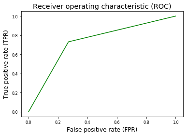

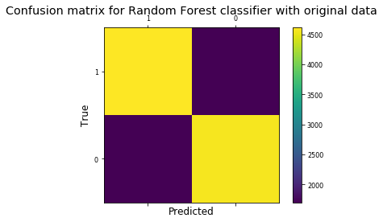

```python
labels = list(modelDataTraining.IntensityLabel.unique())
print(labels)
yPred = rf.predict(xTest)
#print('RF classification score = ', rf.score(xTest, yTest))
cm = confusion_matrix(yTest, yPred, labels)
print('Accuracy: ' + str(np.round(100*float(cm[0][0]+cm[1][1])/float((cm[0][0]+cm[1][1] + cm[1][0] + cm[0][1])),2))+'%')
print('Recall: ' + str(np.round(100*float((cm[1][1]))/float((cm[1][0]+cm[1][1])),2))+'%')
print('Confusion matrix:')
print(cm)

fpr, tpr, _ = roc_curve(yTest, yPred)
auc = np.trapz(fpr,tpr)
print('Area under the ROC curve: ' + str(auc))

fig = plt.figure(1)
plt.plot(fpr,tpr,color='green')
plt.xlabel('False positive rate (FPR)')
plt.ylabel('True positive rate (TPR)')
plt.title('Receiver operating characteristic (ROC)')

fig = plt.figure(2)
ax = fig.add_subplot(111)
cax = ax.matshow(cm)
plt.title('Confusion matrix for Random Forest classifier with original data')
fig.colorbar(cax)
ax.set_xticklabels([''] + labels)
ax.set_yticklabels([''] + labels)
plt.xlabel('Predicted')
plt.ylabel('True')
plt.show()
```

#### Review RF Predictor Importance for feature selection

```python
# Get numerical feature importances
importances = list(rf.feature_importances_)
# List of tuples with variable and importance
feature_importances = [(feature, round(importance, 2)) for feature, importance in zip(feature_list, importances)]
# Sort the feature importances by most important first
feature_importances = sorted(feature_importances, key = lambda x: x[1], reverse = True)
# Print out the feature and importances
[print('Variable: {:20} Importance: {}'.format(*pair)) for pair in feature_importances];
```

```
Variable: Vehicle_Type         Importance: 0.1
Variable: circleDistLL         Importance: 0.09
Variable: Unnamed: 0           Importance: 0.08
Variable: Age_of_Driver        Importance: 0.07
Variable: 1st_Road_Number      Importance: 0.06
Variable: Vehicle_Manoeuvre    Importance: 0.06
Variable: Month                Importance: 0.05
Variable: Day_of_Week          Importance: 0.04
Variable: Vehicle_Reference    Importance: 0.04
Variable: 1st_Point_of_Impact  Importance: 0.03
Variable: Age_Band_of_Driver   Importance: 0.03
Variable: HourSlot             Importance: 0.03
Variable: Journey_Purpose_of_Driver Importance: 0.03
Variable: Number_of_Casualties Importance: 0.03
Variable: 1st_Road_Class       Importance: 0.02
Variable: Junction_Detail      Importance: 0.02
Variable: Junction_Location    Importance: 0.02
Variable: Road_Type            Importance: 0.02
Variable: Sex_of_Driver        Importance: 0.02
Variable: Skidding_and_Overturning Importance: 0.02
Variable: Speed_limit          Importance: 0.02
Variable: Vehicle_Leaving_Carriageway Importance: 0.02
Variable: Weather_Conditions   Importance: 0.02
Variable: Hit_Object_in_Carriageway Importance: 0.01
Variable: Hit_Object_off_Carriageway Importance: 0.01
Variable: Light_Conditions     Importance: 0.01
Variable: Pedestrian_Crossing-Physical_Facilities Importance: 0.01
Variable: Road_Surface_Conditions Importance: 0.01
Variable: Urban_or_Rural_Area  Importance: 0.01
Variable: Carriageway_Hazards  Importance: 0.0
Variable: Pedestrian_Crossing-Human_Control Importance: 0.0
Variable: Special_Conditions_at_Site Importance: 0.0
Variable: Towing_and_Articulation Importance: 0.0
Variable: Vehicle_Left_Hand_Drive Importance: 0.0
Variable: Vehicle_Location-Restricted_Lane Importance: 0.0
```

```python
feature_import = pd.DataFrame(data=rf.feature_importances_, index=xTrain.columns.values, columns=['values'])
feature_import.sort_values(['values'], ascending=False, inplace=True)
feature_import.transpose()
```

|  | Vehicle_Type | circleDistLL | Unnamed: 0 | Age_of_Driver | Vehicle_Manoeuvre | 1st_Road_Number | Month | Day_of_Week | Vehicle_Reference | HourSlot | ... | Hit_Object_off_Carriageway | Road_Surface_Conditions | Urban_or_Rural_Area | Hit_Object_in_Carriageway | Vehicle_Location-Restricted_Lane | Special_Conditions_at_Site | Carriageway_Hazards | Towing_and_Articulation | Pedestrian_Crossing-Human_Control | Vehicle_Left_Hand_Drive |
| --- | --- | --- | --- | --- | --- | --- | --- | --- | --- | --- | --- | --- | --- | --- | --- | --- | --- | --- | --- | --- | --- |
| values | 0.101581 | 0.0866 | 0.080363 | 0.067145 | 0.062775 | 0.060296 | 0.051291 | 0.042044 | 0.038212 | 0.030552 | ... | 0.014446 | 0.014318 | 0.009512 | 0.006949 | 0.004114 | 0.003542 | 0.002775 | 0.001495 | 0.00093 | 0.00058 |

1 rows × 35 columns

#### Visualisation of RF Predictor Importance

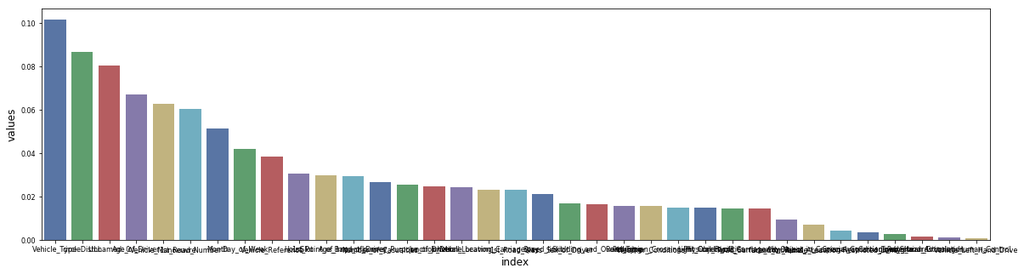

```python
feature_import.reset_index(level=0, inplace=True)
plt.figure(figsize=(20,5))
sns.barplot(x='index', y='values', data=feature_import, palette='deep')
plt.show()
```

### Testing prediction on 2016 data

```python
csvDataTesting = pd.read_csv("BinarySeverity2016.csv")
print('Sparsity per variable in the dataset ==>')
((len(csvDataTesting.index) - csvDataTesting.count())/len(csvDataTesting.index))#Sparsity per variable retained
csvDataTesting.drop(['LSOA_of_Accident_Location'],axis=1,inplace=True)
csvDataTesting.drop(['Fatal','Serious','Slight','Number_of_Vehicles','Pedestrian_Count'], axis=1, inplace=True)
csvDataTesting.drop(['Accident_Severity','Total Casualities'], axis=1, inplace=True)
modelDataTestingForGeoMapping = csvDataTesting.copy(deep=True)
csvDataTesting.drop(['Latitude','Longitude'],axis=1,inplace=True)
csvDataTesting.reset_index()
predictors = list(csvDataTesting.columns)
print('Total no. of predictors ==> ',len(predictors))
print('Predictors ==> ', predictors)
print('Datatype of variables ==> ')
print(csvDataTesting.dtypes.value_counts())
csvDataTesting.to_csv('datasetForModeling.csv')
print('Printing sample records from dataset ==>')
csvDataTesting.head(2)
```

```
Sparsity per variable in the dataset ==>
Total no. of predictors ==>  36
Predictors ==>  ['Unnamed: 0', 'Vehicle_Reference', 'Vehicle_Type', 'Towing_and_Articulation', 'Vehicle_Manoeuvre', 'Vehicle_Location-Restricted_Lane', 'Junction_Location', 'Skidding_and_Overturning', 'Hit_Object_in_Carriageway', 'Vehicle_Leaving_Carriageway', 'Hit_Object_off_Carriageway', '1st_Poin…
Datatype of variables ==>
float64    26
int64      10
dtype: int64
Printing sample records from dataset ==>
```

|  | Unnamed: 0 | Vehicle_Reference | Vehicle_Type | Towing_and_Articulation | Vehicle_Manoeuvre | Vehicle_Location-Restricted_Lane | Junction_Location | Skidding_and_Overturning | Hit_Object_in_Carriageway | Vehicle_Leaving_Carriageway | ... | Light_Conditions | Weather_Conditions | Road_Surface_Conditions | Special_Conditions_at_Site | Carriageway_Hazards | Urban_or_Rural_Area | circleDistLL | Month | HourSlot | IntensityLabel |
| --- | --- | --- | --- | --- | --- | --- | --- | --- | --- | --- | --- | --- | --- | --- | --- | --- | --- | --- | --- | --- | --- |
| 0 | 0 | 1 | 8.0 | 0.0 | 6.0 | 0.0 | 0.0 | 0.0 | 0.0 | 0.0 | ... | 5.0 | 1.0 | 1.0 | 0.0 | 0.0 | 1 | 14.118149 | 11 | 1 | 0 |
| 1 | 1 | 2 | 2.0 | 0.0 | 18.0 | 0.0 | 0.0 | 0.0 | 0.0 | 0.0 | ... | 5.0 | 1.0 | 1.0 | 0.0 | 0.0 | 1 | 14.118149 | 11 | 1 | 0 |

2 rows × 36 columns

```python
xTesting = csvDataTesting[csvDataTesting.columns.difference(['IntensityLabel'])]
yTesting = csvDataTesting.loc[:, csvDataTesting.columns == 'IntensityLabel']
print('Dataset columns ==> ', xTesting.columns)
print('Dataset label ==> ', yTesting.columns)
print(xTesting.dtypes.value_counts())
```

```
Dataset columns ==>  Index(['1st_Point_of_Impact', '1st_Road_Class', '1st_Road_Number',
       'Age_Band_of_Driver', 'Age_of_Driver', 'Carriageway_Hazards',
       'Day_of_Week', 'Hit_Object_in_Carriageway',
       'Hit_Object_off_Carriageway', 'HourSlot', 'Journey_Purpose_of_Driver',
       'Junction_Detail', 'Junction_Location', 'Light_Conditions', 'Month',
       'Number_of_Casualties', 'Pedestrian_Crossing-Human_Control',
       'Pedestrian_Crossing-Physical_Facilities', 'Road_Surface_Conditions',
       'Road_Type', 'Sex_of_Driver', 'Skidding_and_Overturning',
       'Special_Conditions_at_Site', 'Speed_limit', 'Towing_and_Articulation',
       'Unnamed: 0', 'Urban_or_Rural_Area', 'Vehicle_Leaving_Carriageway',
       'Vehicle_Left_Hand_Drive', 'Vehicle_Location-Restricted_Lane',
       'Vehicle_Manoeuvre', 'Vehicle_Reference', 'Vehicle_Type',
       'Weather_Conditions', 'circleDistLL'],
      dtype='object')
Dataset label ==>  Index(['IntensityLabel'], dtype='object')
float64    26
int64       9
dtype: int64
```

#### Classifier performance on Hold-out test set from 2016 data

```
Accuracy: 72.06%
Recall: 72.13%
Confusion matrix:
[[ 16017   6425]
 [ 59427 153828]]
Area under the ROC curve: 0.270123542956
```

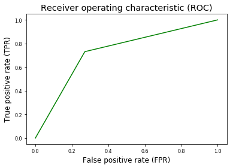

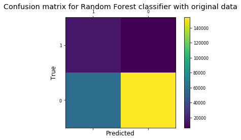

```python
yPredTesting = rf.predict(xTesting)
#print('RF classification score = ', rf.score(xTesting, yTesting))
cm = confusion_matrix(yTesting, yPredTesting, labels)
print('Accuracy: ' + str(np.round(100*float(cm[0][0]+cm[1][1])/float((cm[0][0]+cm[1][1] + cm[1][0] + cm[0][1])),2))+'%')
print('Recall: ' + str(np.round(100*float((cm[1][1]))/float((cm[1][0]+cm[1][1])),2))+'%')
print('Confusion matrix:')
print(cm)

fpr, tpr, _ = roc_curve(yTest, yPred)
auc = np.trapz(fpr,tpr)
print('Area under the ROC curve: ' + str(auc))

fig = plt.figure(1)
plt.plot(fpr,tpr,color='green')
plt.xlabel('False positive rate (FPR)')
plt.ylabel('True positive rate (TPR)')
plt.title('Receiver operating characteristic (ROC)')

fig = plt.figure(2)
ax = fig.add_subplot(111)
cax = ax.matshow(cm)
plt.title('Confusion matrix for Random Forest classifier with original data')
fig.colorbar(cax)
ax.set_xticklabels([''] + labels)
ax.set_yticklabels([''] + labels)
plt.xlabel('Predicted')
plt.ylabel('True')
plt.show()
```

##### F-score

```python
print('Classifier performance ==> \n',classification_report(yTesting, yPredTesting))
```

```
Classifier performance ==>
              precision    recall  f1-score   support

          0       0.96      0.72      0.82    213255
          1       0.21      0.71      0.33     22442

avg / total       0.89      0.72      0.78    235697
```

```python
actualGeoMapping = modelDataTestingForGeoMapping.copy(deep=True)
actualGeoMapping = actualGeoMapping.loc[:,['Latitude','Longitude','IntensityLabel']]
predictedGeoMapping = modelDataTestingForGeoMapping.copy(deep=True)
predictedGeoMapping = predictedGeoMapping.loc[:,['Latitude','Longitude']]
predictedGeoMapping['IntensityLabel'] = pd.Series(yPredTesting)
```

```python
geoMapping = actualGeoMapping['IntensityLabel'].isin(predictedGeoMapping['IntensityLabel']).astype(int)
print('Match percentage = ',((sum(geoMapping)/len(geoMapping))*100),'%')
```

```
Match percentage =  100.0 %
```

#### Visualisation of predicted and actual hotspots for 2016

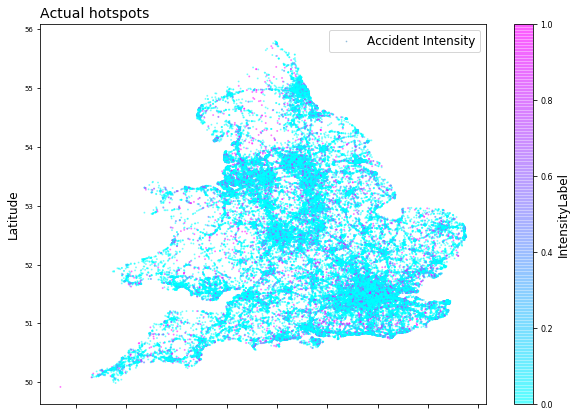

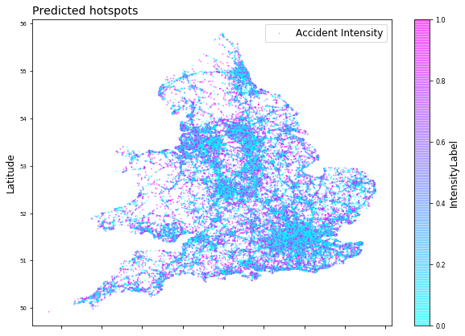

```python
plt.figure(figsize=(15,15))
actualGeoMapping.plot(kind="scatter", x="Longitude", y="Latitude",
    s=actualGeoMapping['IntensityLabel'].unique().tolist(),
    label="Accident Intensity",
    c="IntensityLabel", cmap=plt.get_cmap("cool"),
    #c="Accident_Severity", cmap=cmap,
    colorbar=True, alpha=0.4, figsize=(10,7),
)
plt.legend()
plt.title('Actual hotspots',loc='left',fontsize=14)
plt.xticks(fontsize=7)
plt.yticks(fontsize=7)
plt.show()

predictedGeoMapping.plot(kind="scatter", x="Longitude", y="Latitude",
    s=predictedGeoMapping['IntensityLabel'].unique().tolist(),
    label="Accident Intensity",
    c="IntensityLabel", cmap=plt.get_cmap("cool"),
    #c="Accident_Severity", cmap=cmap,
    colorbar=True, alpha=0.4, figsize=(10,7),
)
plt.legend()
plt.title('Predicted hotspots',loc='left',fontsize=14)
plt.xticks(fontsize=7)
plt.yticks(fontsize=7)
plt.show()
```

1) Classifier seems to be more biased towards High Intensity class. This is due to more weightage for severity in the derived label. 2) Extensive grid search shall improve performance substantially. Not much training was done due to lengthy training time. 3) Use of SMOTE instead of undersampling shall help in using more data from Low Intensity class. This is highly likely to improve performance

```python
print('Overall execution took [', datetime.now() - startTime, '] seconds.')
```

```
Overall execution took [ 0:02:06.377620 ] seconds.
```